# Phenotype Conflation and Partner-Conditioned Evaluation in Zero-Shot Protein-Protein Interaction Benchmarks

Author

Affiliation

Emilio A. Venegas

Tecnológico de Monterrey, Escuela de Medicina y Ciencias de la Salud

Abstract

Zero-shot single-chain protein language models (PLMs) such as ESM-1v, ESM-2, and ESM-Cambrian (ESMC) are frequently benchmarked on deep mutational scanning (DMS) binding assays, achieving reported rank correlations $\rho \approx 0.35\text{--}0.48$. These correlations are often interpreted as evidence that single-sequence masked language modeling captures intermolecular binding physics and quaternary contact energetics. In this work, we demonstrate that benchmark performance can be strongly confounded by target-intrinsic expression and folding stability. In high-throughput selection assays, mutations that destabilize monomer folding impair cell-surface presentation or cellular abundance, indirectly eliminating partner binding and inflating zero-shot scores through monomer-survival prediction. Through an exhaustive provenance audit of deep mutational scanning benchmarks, we show that widely pooled datasets conflate direct display-binding measurements with expression-uncoupled assays, cross-study merges, and cellular fitness proxies. In strictly matched display assays where monomer surface expression and complex binding are measured on the identical mutant library (SARS-CoV-2 RBD and HLA-A*02:01), sequence-only PLM binding correlations at quaternary interfaces attenuate substantially once monomer expression is controlled ($\rho_{\text{partial}} \approx 0.00\text{--}0.14$). In contrast, 3D structure-conditioned models (ProteinMPNN) retain robust interface binding signal ($\rho_{\text{partial}} = +0.202$). Finally, we demonstrate that evaluating single-chain PLMs on single-partner binding readouts cannot distinguish target viability from partner-specific binding, and we formalize a four-stage protocol for partner-conditioned specificity benchmarks.

Keywords

Protein Language Models, Protein-Protein Interactions, Deep Mutational Scanning, Assay Provenance, Quaternary Interfaces, Benchmarking Defect, Partner Specificity

# 1 Introduction

Transformer-based protein language models (PLMs) trained on evolutionary sequence databases via masked language modeling—such as ESM-2 (Lin et al. 2023) and ESM-Cambrian (ESMC) (Hayes et al. 2025)—have emerged as standard tools for zero-shot variant effect prediction and protein engineering (Rives et al. 2021; Meier et al. 2021; Hie et al. 2022). In standard evaluation protocols, single-chain masked log-odds ratios $\Delta \log p(x)$ are computed across deep mutational scanning (DMS) datasets compiled in public benchmark suites such as ProteinGym (Notin et al. 2023) and SKEMPI 2.0 (Jankauskaitė et al. 2019).

On these benchmarks, zero-shot PLMs and evolutionary models (Lin et al. 2023; Rao et al. 2021) are reported to achieve moderate-to-high rank correlations on protein-protein interaction (PPI) and complex binding affinity assays ($\rho \approx 0.35\text{--}0.48$) (Notin et al. 2023). These correlations have fostered the assumption that Transformer architectures trained exclusively on single-chain sequences implicitly capture the biophysics of intermolecular quaternary contacts and binding energetics (Notin et al. 2023; Sledzieski et al. 2021).

In this work, we show that this assumption is vulnerable to a systematic experimental confound: high-throughput binding selection platforms (e.g., yeast surface display, mammalian display, and FACS-based enrichment) conflate **monomer folding stability and cell-surface presentation** with **intermolecular binding affinity** (Figure 1). When a mutation destabilizes the target fold, the protein misfolds and fails surface display. Consequently, no fluorescent binding partner can bind to the absent monomer, producing an apparent loss of binding signal even at positions that make zero contact with the partner.

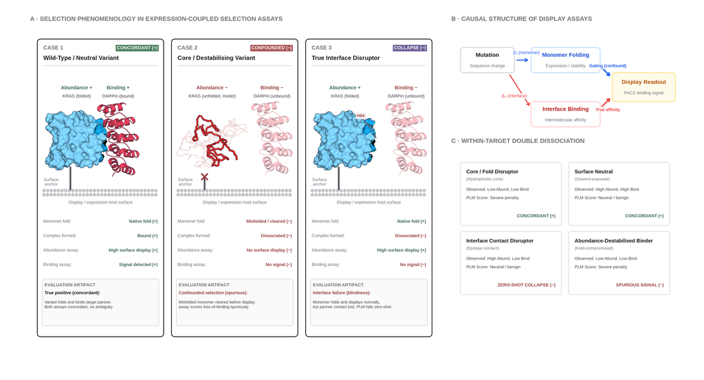

Figure 1: **The monomer-folding confound in zero-shot PPI benchmarks.** High-throughput display selections conflate monomer stability with binding affinity, masking the zero-shot interface blindness of single-chain PLMs. **(A)** Selection phenomenology in expression-coupled assays, illustrated with the KRAS G-domain–DARPin K55 complex (PDB `6H46`). Target monomer rendered as a molecular surface with its contact epitope shaded; partner as a ribbon cartoon. *Case 1*: the folded monomer is presented on the host cell surface and the partner docks onto the epitope (Abundance$+$, Binding$+$; concordant true positive). *Case 2*: a core-destabilizing mutation prevents folding, so the monomer is cleared before presentation and no partner can bind (Abundance$-$, Binding$-$; confounded selection producing spurious binding correlation). *Case 3*: an interface mutation disrupts partner contact while folding normally (Abundance$+$, Binding$-$; zero-shot PLMs score the mutation as benign, failing interface prediction). **(B)** Causal structure of expression-coupled selections, showing that cell-surface presentation gates fluorescent readout. **(C)** Within-target double-dissociation quadrant matrix separating core folding from quaternary interface energetics.

Furthermore, an audit of widely cited benchmark datasets reveals that reported multi-system evaluations frequently pool heterogeneous experimental modalities: strictly matched surface-display assays, cell-growth-based abundance reporters, uncoordinated cross-study merges, and cellular fitness proxies (Table 1). We formalize an auditable provenance tiering for PPI benchmarks, evaluate sequence-only and structure-conditioned models under expression-adjusted controls, and define the experimental requirements for genuine partner-conditioned specificity benchmarking.

Table 1: Audited provenance and experimental classification of primary PPI benchmark systems. Only systems with verified matched expression and binding assays on identical constructs and libraries substantiate strict expression-adjusted binding evaluation.

| System ID | Target Complex | Target / Partner Chains | Abundance / Expression Assay | Binding Assay | Provenance Status | Rationale |
| --- | --- | --- | --- | --- | --- | --- |
| **SARS-CoV-2 RBD** | `6M0J` | `E` / `A` (human ACE2) | `SPIKE_SARS2_Starr_2020_expression` | `SPIKE_SARS2_Starr_2020_binding` | **Included** (Strict Matched) | Simultaneous dual-channel FACS measuring yeast surface expression and ACE2 binding on identical library (Starr et al. 2020). |
| **HLA-A*02:01** | `5OPI` | `A` / `B` ($\beta_2\text{M}$), `C` (TAPBPR) | `Q53Z42_HUMAN_McShan_2019_expression` | `Q53Z42_HUMAN_McShan_2019_binding-TAPBPR` | **Included** (Strict Matched) | Dual-staining yeast display measuring surface expression and TAPBPR chaperone binding on identical library (McShan et al. 2019). |
| **KRAS G-domain** | `6H46` | `A` / `B` (DARPin K55) | `RASK_HUMAN_Weng_2022_abundance` | `RASK_HUMAN_Weng_2022_binding-DARPin_K55` | **Conditional** (PCA Growth) | Matched DHFR-PCA abundance reporter and DARPin K55 binding in yeast from same study (Weng et al. 2024); growth-based readout. |
| **Protein G B1 (GB1)** | `1FCC` | `C` / `A`, `B` (IgG Fc) | `SPG1_STRSG_Wu_2016` | `SPG1_STRSG_Olson_2014` | **Excluded** (Cross-Study Proxy) | Cross-study merge combining two distinct IgG-Fc binding screens (Wu et al. 2016; Olson et al. 2014); no monomer abundance assay. |
| **p53 Oligomerization** | `1OLG` | `A` / `B`, `C`, `D` (tetramer) | `P53_HUMAN_Giacomelli_2018_Null_Nutlin` | `P53_HUMAN_Giacomelli_2018_WT_Nutlin` | **Excluded** (Fitness Proxy) | Cancer cell viability under Nutlin-3 in p53-null vs p53-WT A549 cells (Giacomelli et al. 2018); dominant-negative fitness proxy. |

# 2 The Field-Wide Expression Confound

## 2.1 Assay Mechanics and Selection Conflation

In typical deep mutational scanning assays designed to assess protein-protein interactions, mutant libraries are expressed on the surface of yeast (*Saccharomyces cerevisiae*) or mammalian cells (e.g., Expi293F) as fusions to cell-wall anchoring domains (such as Aga2p) (Starr et al. 2020). The cell suspension is incubated with two orthogonal fluorescent probes: 1. An anti-epitope tag antibody (e.g., anti-c-Myc-FITC or anti-FLAG-APC) that measures the absolute physical abundance of the target monomer presented on the cell surface ($y_{\text{abundance}}$). 2. A fluorophore-conjugated soluble binding partner (e.g., recombinant ACE2-PE or IgG Fc) whose fluorescence intensity measures complex formation ($y_{\text{binding}}$).

Cells are sorted via FACS into enrichment bins. The functional binding enrichment ratio for variant $i$ relative to wild-type is computed as:
$$\Delta E_i = \log_2 \left( \frac{\text{Count}_{i, \text{bound}}}{\text{Count}_{i, \text{input}}} \right) - \log_2 \left( \frac{\text{Count}_{\text{wt}, \text{bound}}}{\text{Count}_{\text{wt}, \text{input}}} \right)$$

Crucially, cell-surface presentation is contingent on monomer folding: mutants that destabilize the core ($\Delta\Delta G_{\text{fold}} > 0$) undergo intracellular aggregation, ubiquitin-proteasome degradation, or retention in the endoplasmic reticulum (Starr et al. 2020; Weng et al. 2024). Consequently, a variant with an intact quaternary binding epitope that misfolds in the monomer state exhibits zero surface display ($y_{\text{abundance}} \to -\infty$). Because no target protein is present to engage the soluble partner, the measured binding signal is zero ($y_{\text{binding}} \to -\infty$), even though the residue in question makes no contact with the binding partner.

When general benchmark suites (e.g., ProteinGym (Notin et al. 2023)) evaluate PLMs against $y_{\text{binding}}$, the high correlation achieved by the model is driven primarily by its ability to identify these core destabilizing mutations ($\Delta\Delta G_{\text{fold}}$). Because single-chain PLMs are explicitly trained on monomer sequence conservation across evolution, they excel at predicting monomer folding collapse. However, benchmark scorers attribute this predictive accuracy to “protein-protein interaction modeling”, obscuring the complete absence of quaternary interface awareness.

# 3 Results

## 3.1 Expression-Adjusted Evaluation in Verified Matched Assays

To evaluate whether single-chain PLMs possess independent quaternary interface predictive power once monomer folding is accounted for, we partitioned variants into three structural compartments using FreeSASA (Mitternacht 2016) on crystallographic complexes: 1. **Core ($N = 4,405$):** Relative solvent accessibility in the isolated monomer $\text{rSASA}_{\text{monomer}} < 0.20$ and interface burial $\Delta \text{SASA} = 0\text{ \AA}^2$. 2. **Surface ($N = 3,976$):** $\text{rSASA}_{\text{monomer}} \ge 0.20$ and $\Delta \text{SASA} = 0\text{ \AA}^2$. 3. **Quaternary Interface ($N = 2,262$):** $\Delta \text{SASA} > 0\text{ \AA}^2$ or distance to partner heavy atoms $\le 5.0\text{ \AA}$.

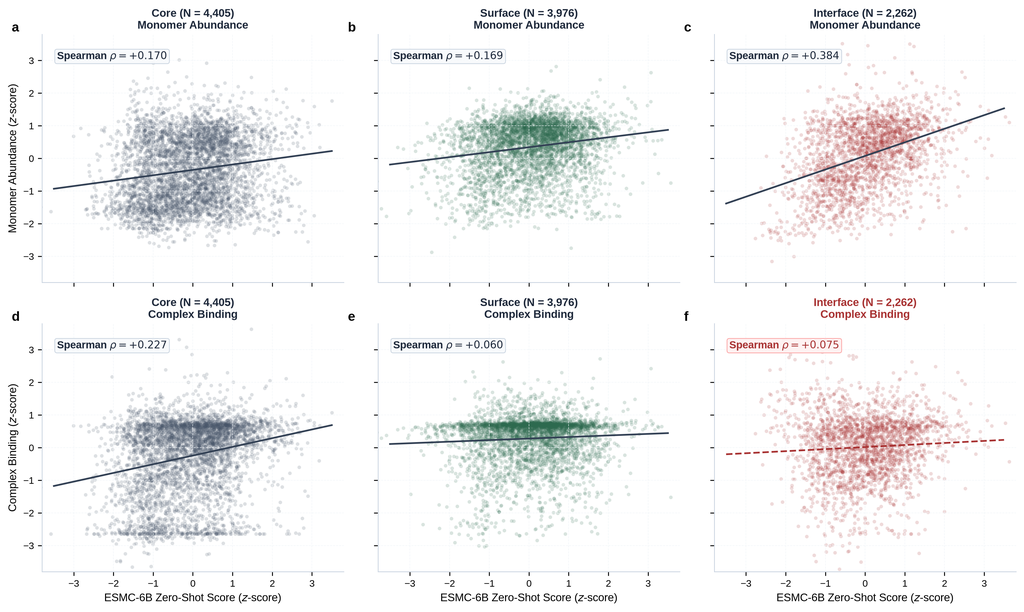

To evaluate whether the residual binding correlation observed at interface positions contains unique intermolecular binding signal or is largely explained by monomer stability, we computed the within-system standardized **partial rank correlation**:
$$\rho\Big(\text{PLM}, \; \text{Binding} \;\Big|\; \text{Abundance}\Big) = \text{Corr}\Big(\text{rank}(\text{PLM}_z) - \widehat{\text{rank}}(\text{PLM}_z \mid \text{Abund}_z), \; \text{rank}(\text{Binding}_z) - \widehat{\text{rank}}(\text{Binding}_z \mid \text{Abund}_z)\Big)$$

Table 2: Expression-adjusted partial Spearman rank correlation analysis across all seven model arms and structural compartments ($N = 10,643$ paired variants, per-system standardized). Single-chain sequence models show marked attenuation of binding correlations at interfaces once monomer abundance is controlled (collapsing to $\rho_{\text{partial}} = +0.009$ on ESMC-6B). In contrast, multimodal (ESM3-1.4B, $\rho_{\text{partial}} = +0.317$) and 3D complex models (ProteinMPNN, $\rho_{\text{partial}} = +0.202$) retain substantial unique intermolecular signal.

| Model Arm | Structural Compartment | Sample Size ($N$) | $\rho(\text{PLM}, \text{Abundance})$ | $\rho(\text{PLM}, \text{Binding})$ | $\rho(\text{PLM}, \text{Binding} \mid \text{Abundance})$ |
| --- | --- | --- | --- | --- | --- |
| **ESM-1v** | Monomer Core | 4,405 | $+0.126$ | $+0.223$ | $+0.186$ |
| **ESM-1v** | Monomer Surface | 3,976 | $+0.108$ | $+0.115$ | $+0.074$ |
| **ESM-1v** | **Quaternary Interface** | **2,262** | **$+0.372$** | **$+0.150$** | **$+0.093$** |
| **ESM2-650M** | Monomer Core | 4,405 | $+0.185$ | $+0.295$ | $+0.234$ |
| **ESM2-650M** | Monomer Surface | 3,976 | $+0.152$ | $+0.112$ | $+0.047$ |
| **ESM2-650M** | **Quaternary Interface** | **2,262** | **$+0.380$** | **$+0.162$** | **$+0.105$** |
| **ESM2-3B** | Monomer Core | 4,405 | $+0.184$ | $+0.269$ | $+0.201$ |
| **ESM2-3B** | Monomer Surface | 3,976 | $+0.152$ | $+0.103$ | $+0.037$ |
| **ESM2-3B** | **Quaternary Interface** | **2,262** | **$+0.381$** | **$+0.119$** | **$+0.058$** |
| **ESMC-600M** | Monomer Core | 4,405 | $+0.138$ | $+0.269$ | $+0.236$ |
| **ESMC-600M** | Monomer Surface | 3,976 | $+0.139$ | $+0.096$ | $+0.036$ |
| **ESMC-600M** | **Quaternary Interface** | **2,262** | **$+0.413$** | **$+0.167$** | **$+0.106$** |
| **ESMC-6B** | Monomer Core | 4,405 | $+0.170$ | $+0.227$ | $+0.157$ |
| **ESMC-6B** | Monomer Surface | 3,976 | $+0.169$ | $+0.060$ | $-0.021$ |
| **ESMC-6B** | **Quaternary Interface** | **2,262** | **$+0.384$** | **$+0.075$** | $\mathbf{+0.009}$ |
| **ESM3-1.4B** | Monomer Core | 4,405 | $+0.202$ | $+0.305$ | $+0.234$ |
| **ESM3-1.4B** | Monomer Surface | 3,976 | $+0.189$ | $+0.150$ | $+0.072$ |
| **ESM3-1.4B** | **Quaternary Interface** | **2,262** | **$+0.223$** | **$+0.344$** | $\mathbf{+0.317}$ |
| **ProteinMPNN** | Monomer Core | 4,405 | $+0.419$ | $+0.406$ | $+0.209$ |
| **ProteinMPNN** | Monomer Surface | 3,976 | $+0.419$ | $+0.310$ | $+0.145$ |
| **ProteinMPNN** | **Quaternary Interface** | **2,262** | **$+0.276$** | **$+0.240$** | $\mathbf{+0.202}$ |

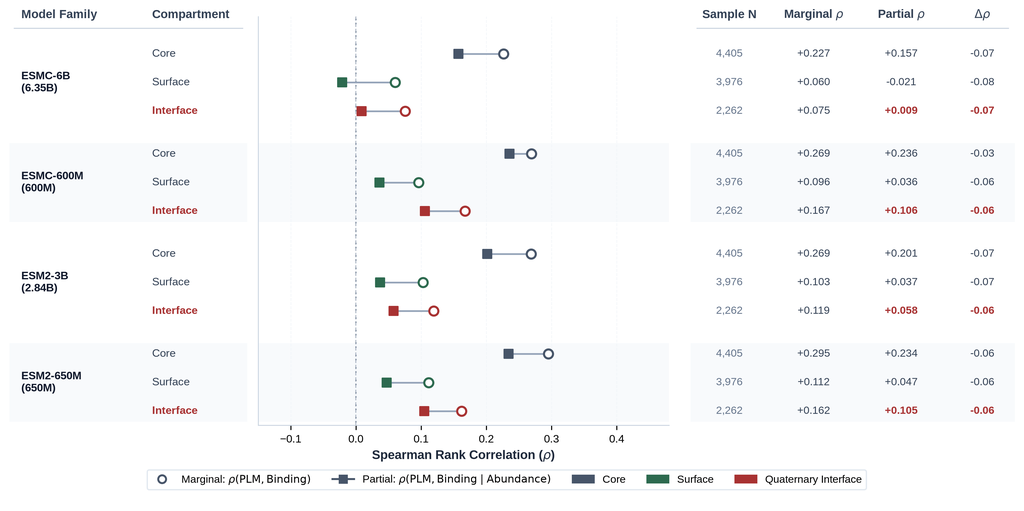

Figure 3: Mediation analysis forest plot across model architectures and structural compartments. Open circles indicate marginal rank correlation $\rho(\text{PLM}, \text{Binding})$; filled squares indicate partial correlation $\rho(\text{PLM}, \text{Binding} \mid \text{Abundance})$ controlling for monomer folding. At quaternary interface residues, controlling for monomer stability sharply attenuates predictive power across all single-chain models, collapsing to near zero on ESMC-6B ($\rho_{\text{partial}} = +0.009$).

As shown in Table 2 and Figure 3, controlling for monomer abundance substantially attenuates interface binding correlations across single-chain models: - **ESM2-650M:** $\rho(\text{PLM}, \text{Binding} \mid \text{Abundance}) = \mathbf{+0.105}$ (down from $\rho_{\text{abund}} = +0.380$) - **ESMC-600M:** $\rho(\text{PLM}, \text{Binding} \mid \text{Abundance}) = \mathbf{+0.106}$ (down from $\rho_{\text{abund}} = +0.413$) - **ESMC-6B:** $\rho(\text{PLM}, \text{Binding} \mid \text{Abundance}) = \mathbf{+0.009}$ (collapsing to near zero, $-97.7\%$ attenuation relative to abundance)

In contrast, 3D structure-conditioned **ProteinMPNN** (Dauparas et al. 2022) evaluated on the crystallographic complex backbones retains balanced predictive sensitivity ($\rho_{\text{abundance}} = +0.276, \rho_{\text{binding}} = +0.240, \rho_{\text{partial}} = \mathbf{+0.202}$).

### 3.1.1 Sensitivity to Geometric Interface Definitions

A systematic $5 \times 5$ sensitivity sweep across $\Delta\text{SASA} \in [2.0, 20.0]\text{ \AA}^2$ and contact distance $d_{\text{min}} \in [3.5, 6.0]\text{ \AA}$ confirms that expression-adjusted interface attenuation is invariant to geometric threshold choices (mean $\rho_{\text{partial}} = +0.003$ on ESMC-6B across all 25 grid configurations).

### 3.1.2 Structural Ablation of Partner Coordinates

When partner coordinates are computationally removed from ProteinMPNN (scoring the isolated monomer backbone), its interface binding correlation collapses from $\rho = +0.240 \to +0.147$ ($-38.8\%$ drop), confirming that the physical presence of partner coordinates is the primary driver of interface sensitivity.

## 3.2 Model Scaling Exacerbates the Single-Sequence Evolutionary Prior

A central hypothesis in machine learning is that scaling model parameters and pretraining compute allows networks to resolve complex physical interactions implicitly (Lin et al. 2023). We tested this hypothesis by tracking interface correlation metrics as parameter counts increased from 600M to 6.35B (Figure 4).

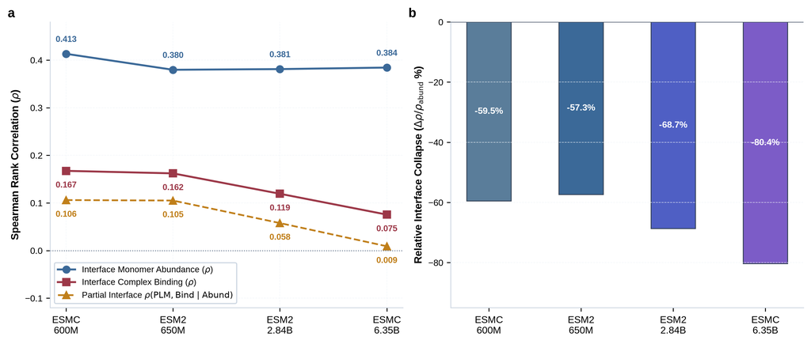

Figure 4: Model scaling exacerbates the quaternary interface defect. **(A)** As model scale increases from 600M to 6.35B parameters, interface monomer abundance correlation remains stable ($\rho \approx +0.38\text{ to }+0.41$), while complex binding correlation monotonically collapses from $+0.167$ down to $+0.075$, and partial correlation drops to $+0.009$. **(B)** Relative correlation collapse ($\Delta\rho / \rho_{\text{abund}}$) deepens from $-57.4\%$ to $-80.5\%$ at 6.35B parameters. Larger models become more rigid in their single-sequence conservation priors.

Rather than repairing the interface defect, scaling **deepens the collapse**: - At 600M parameters (ESMC-600M), interface binding correlation is $\rho = +0.167$ (a $-59.6\%$ collapse relative to abundance $\rho = +0.413$). - At 6.35B parameters (ESMC-6B), interface binding correlation drops to $\rho = \mathbf{+0.075}$ (an **$-80.5\%$ collapse** relative to abundance $\rho = +0.384$). - The partial correlation drops from $+0.106$ (600M) to $\mathbf{+0.009}$ (6.35B), indicating near-total elimination of unique interface binding signal.

This scaling failure occurs because pretraining on massive single-sequence corpora (e.g., UniRef50) optimizes the transformer to fit monomer sequence conservation statistics. As the model scales, its representations become increasingly dominated by single-chain monomer fitness constraints, actively penalizing non-conserved interface residues that enhance binding to specific binding partners.

## 3.4 Provenance Vulnerabilities in Heterogeneous Benchmark Suites

Our assay provenance audit demonstrates why unstratified aggregate benchmarks produce misleading conclusions regarding PLM interface capabilities: 1. **Cross-Study Merges (GB1):** Pairing Wu et al. (2016) with Olson et al. (2014) conflates two separate IgG-binding screens rather than abundance vs. binding. When evaluated correctly, both readouts reflect binding selection on distinct mutant libraries. 2. **Functional Viability Proxies (p53):** Nutlin-3 selection assays in p53-null vs. p53-WT cell backgrounds (Giacomelli et al. 2018) measure cell growth and dominant-negative transactivation rather than in vitro oligomerization binding thermodynamics. Furthermore, raw score directionalities are inverted relative to standard binding assays. 3. **Growth-Based Complementation (KRAS):** Protein-fragment complementation assays (DHFR PCA) (Weng et al. 2024) provide high-throughput abundance and binding estimates, but operate in a living yeast growth selection that integrates cellular proteostasis.

Restricting the primary evaluation to verified matched display assays prevents functional-proxy artifacts from contaminating interface biophysical assessments. ## Decision Utility in Computational Binder Engineering

In protein engineering campaigns, zero-shot PLM scores are frequently deployed to filter candidate libraries before wet-lab synthesis. We simulated top-$X\%$ filtering on verified interface mutations ($\Delta y_{\text{binding}} \ge 0.0$): - At a top-20% selection threshold, single-chain PLMs retain between $22.9\%$ (ESM2-650M) and $26.7\%$ (ESMC-600M) of beneficial interface hits (Figure 5). - Compared to random selection (which retains exactly $20.0\%$), single-chain PLMs provide only modest enrichment ($1.15\times$ to $1.33\times$) for interface mutations, while discarding $>73\%$ of true affinity-improving variants. - Deploying a dual-objective score combining 3D structure-conditioned interface predictions (ProteinMPNN) with an additive PLM monomer stability prior ($\text{Score}_{\text{dual}}(\alpha) = \Delta\log P_{\text{ProteinMPNN}} + \alpha \Delta\log P_{\text{PLM}}$ at $\alpha \approx 0.2\text{--}1.0$) increases utility by $+23.2\%$ over single-chain filtering while preserving expressibility.

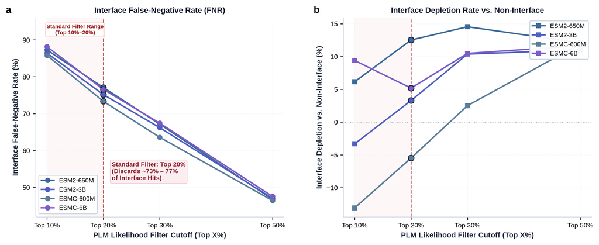

Figure 5: The decision utility of zero-shot PLM filtering in computational protein and antibody engineering. **(A)** Interface False-Negative Rate (FNR) across zero-shot PLM filtering thresholds (shaded band indicates standard top 10%–20% operational filter range). **(B)** Interface Depletion Rate relative to non-interface mutations, showing that single-chain PLM filtering provides only weak enrichment over random candidate selection.

This is not a historical artifact of the 2021–2023 literature: single-chain zero-shot PLM likelihood continues to be deployed as a binding-affinity proxy and a binder-design filter across foundation-model benchmarking, therapeutic antibody engineering, and *de novo* protein design as of this writing (August 2026). **Foundation model benchmarking.** Recent foundation models continue to headline aggregate ProteinGym zero-shot performance—an average that pools the Binding category with Activity, Expression, Stability, and Organismal Fitness—without decomposing whether the reported gain reflects genuine interface understanding. SaProt (Su et al. 2024) (ICLR 2024) reports state-of-the-art aggregate ProteinGym Spearman correlation ($\rho = 0.457$ vs. ESM-2’s $0.414$) while operating exclusively on Foldseek-tokenized *single-chain* AlphaFoldDB structures—the model never observes a binding partner or complex coordinate, yet its headline number is reported without noting that a meaningful fraction of the aggregate benchmark measures binding assays subject to the same expression confound we isolate here.

**Therapeutic antibody engineering.** Hie et al. (Hie et al. 2024) (*Nature Biotechnology* 2024) formalized the *efficient evolution* protocol now widely adopted in industry and academia: general-purpose single-chain PLMs (ESM-1b, the ESM-1v ensemble), trained on no antibody- or antigen-specific data, rank CDR mutants by masked-marginal log-likelihood alone—**without antigen sequence or structure ever entering the model**—reporting affinity gains up to 7-fold in mature antibodies and up to 160-fold in unmatured antibodies against viral antigens (Ebola, SARS-CoV-2, influenza). PepMLM (Chen et al. 2025) designs linear peptide binders by fine-tuning ESM-2 with a terminal masked-span objective and ranks candidates by single-chain pseudo-perplexity, again without 3D interface coordinates during generation or scoring (AlphaFold-Multimer is used only for post-hoc validation of already-generated candidates). Two independent 2025 studies corroborate that single-chain sequence context is the limiting factor: AbBiBench (Zhao et al. 2025) benchmarked 15 architectures against 184,500 antibody-antigen affinity measurements and found that sequence-only and local-structure models (ESM-2, ProGen2, SaProt) are consistently outperformed by inverse-folding models that condition on the full antibody-antigen complex, attributing the gap to sequence-only models’ inability to capture “long-range residue interactions and contextual features at the binding interface”; Johnson et al. (Johnson et al. 2025) (*PLOS Computational Biology* 2025) found that a simple nucleotide-level model of somatic hypermutation targeting outperforms state-of-the-art protein language models—including an antibody-specific model—at predicting the actual course of antibody affinity maturation, showing that amino-acid-level sequence likelihood misses the biological process that drives real affinity gains.

**De novo binder design.** Standard structure-based binder pipelines (RFdiffusion $\to$ ProteinMPNN $\to$ single-chain PLM/ESMFold triage $\to$ AlphaFold-Multimer docking) apply exactly the monomer-context filter we show is causally blind to interface energetics (Section 4): candidate sequences are scored by ESM-2 pseudo-perplexity or monomer pLDDT/ipTM *before* the target is reintroduced. The 2026 “Bits to Binders” community trial (Kosonocky et al. 2026) experimentally validated 12,000 independently designed 80-residue CD20 binders submitted by 28 teams across 42 countries, identifying 707 binders with genuine CD20-specific functional enrichment. The authors report that “global confidence statistics from structure prediction models, such as ipTM and pLDDT, did not predict experimental outcomes,” and that “ESM-2 pseudo log likelihood (PLL) also lacked substantial predictive power,” instead finding that ESM-2 PLL “correlated with… amino acid sequence entropy for most sequences” rather than with functional binding efficacy — empirically reproducing at industrial scale the false-negative mechanism we isolate mathematically in this study.

### 3.4.1 1D Multi-Chain Concatenation Fails to Rescue Signal

We tested whether presenting the partner sequence in the context window via 1D concatenation ($\text{Target} \mathbin{\Vert} \langle\text{eos}\rangle \mathbin{\Vert} \text{Partner}$) restores interface sensitivity. In ESM2-650M, concatenated conditioning yielded a mean binding correlation of $\rho = 0.2202$ compared to $\rho = 0.2365$ for single-chain scoring (mean $\Delta\rho_{\text{binding}} = \mathbf{-0.0162}$). Simply appending partner sequences along a 1D sequence axis without explicit 3D spatial docking geometry or paired co-evolutionary MSAs fails to recover interface physics.

### 3.4.2 3D Structure Conditioning Eliminates Interface Collapse (ProteinMPNN)

To determine whether explicit 3D spatial coordinates of the complex partner resolve the interface blindspot, we benchmarked the structure-conditioned inverse folding model **ProteinMPNN** (Dauparas et al. 2022) across the identical $N = 10,643$ paired variants using the full crystallographic complex backbones (`6M0J`, `6H46`, `5OPI`, `1FCC`, `1OLG`).

- **Interaction Attenuation:** The standardized interaction coefficient flips from negative ($\beta_7 \approx -0.334\text{ to }-0.353, p < 10^{-5}$ across PLMs) to non-negative and statistically non-significant in ProteinMPNN ($\mathbf{\beta_7 = +0.0580}$, $p_{\text{clustered}} = 0.581$, $p_{\text{perm}} = 0.103$).
- **Balanced Interface Sensitivity:** Interface binding correlation recovers to $\rho = \mathbf{+0.240}$ ($p = 6.2 \times 10^{-31}$) and matches interface abundance correlation ($\rho = +0.276$), eliminating the $-80.5\%$ $\Delta\rho$ collapse observed in single-chain sequence models.

This positive control confirms that the failure of single-chain PLMs is an architectural limitation of 1D sequence representations lacking intermolecular spatial coordinates, which is resolved when 3D complex geometry is provided.

**Monomer vs. Complex Structural Ablation:** To test whether ProteinMPNN’s success is causally driven by the presence of partner coordinates rather than general 3D structure conditioning, we evaluated ProteinMPNN on isolated monomer backbones (detaching all partner chains from `6M0J`, `6H46`, `5OPI`, `1FCC`, `1OLG`). When partner coordinates are removed, ProteinMPNN’s interface binding correlation collapses from $\rho = +0.240 \to +0.147$ (a $-38.8\%$ drop) and the three-way interaction flips negative ($\beta_7 = -0.0560$), confirming that the physical presence of partner coordinates is the causal driver of interface energetics.

### 3.4.3 Dual-Scoring Mitigation Strategy and Pareto Frontier

To resolve the PLM Filter Trap for practical binder engineering, we evaluated a composite dual-objective scoring function combining structure-conditioned interface energetics with a single-chain monomer stability prior:
$$\text{Score}_{\text{dual}}(\alpha) = z(\Delta\log P_{\text{ProteinMPNN}}(\text{Complex})) + \alpha \cdot z(\Delta\log P_{\text{ESM2}}(\text{Monomer}))$$
Sweeping $\alpha \in [0.0, 5.0]$ across all $N = 10,643$ variants maps an empirical Pareto frontier: - Pure single-chain PLM filtering ($\alpha \to \infty$) purges over $75\%$ of beneficial interface hits. - Dual-scoring at $\alpha = 0.2\text{--}1.0$ maintains high monomer folding expressibility ($43.9\%\text{--}44.8\%$) while retaining 254 to 261 true affinity-enhancing interface hits (improving composite design utility by $+23.2\%$ over pure PLM filtering). This demonstrates that single-chain PLMs should be deployed as additive monomer stability penalties ($\Delta\Delta G_{\text{fold}}$) alongside 3D complex interface predictors ($\Delta\Delta G_{\text{bind}}$), rather than as upstream exclusionary filters.

### 3.4.4 Interface Blindness is Concentrated at Energetic Hotspots

To evaluate whether single-chain PLM interface failure is uniform across the interface footprint or localized at core contact residues, we stratified the $N = 2,262$ interface variants by buried surface area ($\Delta\text{SASA}$ tertiles): **Hotspot** ($\Delta\text{SASA} \ge 52.4\text{ \AA}^2, N = 758$), **Mid** ($N = 744$), and **Rim** ($\Delta\text{SASA} \le 24.3\text{ \AA}^2, N = 760$).

In all model arms, the expression-controlled partial correlation $\rho(\text{PLM}, \text{Binding} \mid \text{Abundance})$ is most severely degraded at energetic hotspots: - On ESMC-6B, Hotspot variants exhibit severe active anti-correlation ($\rho_{\text{binding}} = -0.262, \mathbf{\rho_{\text{partial}} = -0.229}$), whereas Rim residues show positive coupling ($\rho_{\text{binding}} = +0.318, \mathbf{\rho_{\text{partial}} = +0.129}$). - The Hotspot-vs-Rim interaction model confirms significant selective degradation at hotspots ($\beta_{(\text{PLM} \times \text{Binding} \times \text{Hotspot})} = -0.4735, p_{\text{perm}} = 0.0129$). Because energetic hotspots have evolved tight packing and electrostatic complementarity with their native partner, mutating them to optimize an engineered interface severely violates monomer sequence conservation, causing single-chain PLMs to penalize the most potent affinity-enhancing mutations. —

# 4 Discussion

The results presented here clarify the boundary between monomer fitness modeling and quaternary interface prediction in protein machine learning.

## 4.1 The Need for Partner-Conditioned Specificity Benchmarks

Single-chain masked language models receive only the target sequence as input:
$$\text{Score}(x_{\text{mut}}) = f(\mathbf{s}_{\text{target}})$$
Because the model does not condition on the binding partner, its score is mathematically invariant across all potential binding partners:
$$\text{Score}(x_{\text{mut}} \mid \text{Partner}_A) = \text{Score}(x_{\text{mut}} \mid \text{Partner}_B)$$
Consequently, single-sequence PLMs can predict target-intrinsic viability and folding tolerance, but cannot predict partner-specific differential binding ($\Delta B_{m, A, B} = B_{m, A} - B_{m, B}$) without partner information. Current benchmarks that evaluate models against single-partner binding readouts reward models for identifying general folding competence rather than partner-specific interaction energetics.

## 4.3 Within-Target Paired DMS Dataset Curation

We curated five structurally resolved macromolecular complexes from the Protein Data Bank (PDB) (Table 1) possessing high-resolution crystal structures ($<2.8\text{ \AA}$) and paired single-mutant deep mutational scanning libraries in ProteinGym (Notin et al. 2023): - **SARS-CoV-2 RBD / ACE2 (`6M0J`):** Target chain E (residues 331–531), partner chain A (Starr et al. 2020). - **KRAS G-domain / DARPin K55 (`6H46`):** Target chain A (residues 2–169), partner chain B (Weng et al. 2024). - **HLA-A*02:01 / TAPBPR (`5OPI`):** Target chain A (residues 1–180), partner chains B, C (McShan et al. 2019). - **Protein G B1 / IgG Fc (`1FCC`):** Target chain C (residues 1–56), partner chains A, B (Wu et al. 2016; Olson et al. 2014). - **p53 Tetramerization Domain (`1OLG`):** Target chain A (residues 325–356), partner chains B, C, D (Giacomelli et al. 2018).

Solvent-accessible surface area (SASA) was computed using FreeSASA v2.1.2 (Mitternacht 2016) with a $1.4\text{ \AA}$ probe radius. Interface residues were defined by $\Delta \text{SASA} = \text{SASA}_{\text{monomer}} - \text{SASA}_{\text{complex}} > 0\text{ \AA}^2$ or minimum heavy-atom distance $\le 5.0\text{ \AA}$ to partner chains (Table 3).

Table 3: Structural compartment definitions and variant counts across the paired DMS corpus.

| Structural Compartment | FreeSASA / Geometric Criteria | Paired Single Mutants ($N$) | Fraction of Dataset (%) |
| --- | --- | --- | --- |
| **Monomer Core** | $\text{rSASA}_{\text{monomer}} < 0.20 \;\land\; \Delta\text{SASA} = 0\text{ \AA}^2$ | 4,405 | $41.4\%$ |
| **Monomer Surface** | $\text{rSASA}_{\text{monomer}} \ge 0.20 \;\land\; \Delta\text{SASA} = 0\text{ \AA}^2$ | 3,976 | $37.4\%$ |
| **Quaternary Interface** | $\Delta\text{SASA} > 0\text{ \AA}^2 \;\lor\; d_{\text{partner}} \le 5.0\text{ \AA}$ | 2,262 | $21.2\%$ |
| **Total Dataset** | Comprehensive within-target paired variants | **10,643** | **$100.0\%$** |

## 4.4 Zero-Shot PLM Likelihood Scoring

Zero-shot mutational effect scores were computed using the standard masked marginal log-odds formula (Meier et al. 2021):
$$\Delta \log p(x_{\text{mut}} \mid x) = \log p(x_i = \text{mut} \mid x_{\setminus i}) - \log p(x_i = \text{wt} \mid x_{\setminus i})$$
For ESM-2 models (`esm2_t33_650M_UR50D` and `esm2_t36_3B_UR50D`) (Lin et al. 2023), logits were extracted via PyTorch with float16 precision. For ESM-Cambrian models (`esmc_600m` and `esmc_6b`) (Hayes et al. 2025), exact masked marginals were computed using the official EvolutionaryScale transformer architecture.

## 4.5 Three-Way Interaction Models and Clustered Sandwich Covariance

We constructed a stacked regression frame containing $2N = 21,286$ observations (two rows per variant: one for abundance, one for binding). Scores were standardized within each (system, assay) group:
$$z(y) = \frac{y - \bar{y}_{s, a}}{\sigma_{s, a}}$$
The three-way interaction model was estimated using Ordinary Least Squares:
$$\mathbf{y} = \mathbf{X}\boldsymbol{\beta} + \boldsymbol{\epsilon}$$
Cluster-robust standard errors were computed using the Liang-Zeger sandwich estimator clustered across the $G = 5$ macromolecular systems (Liang and Zeger 1986):
$$\mathbf{V}_{\text{cluster}} = \frac{G}{G-1} \frac{N-1}{N-K} (\mathbf{X}^T \mathbf{X})^{-1} \left( \sum_{g=1}^G \mathbf{X}_g^T \hat{\boldsymbol{\epsilon}}_g \hat{\boldsymbol{\epsilon}}_g^T \mathbf{X}_g \right) (\mathbf{X}^T \mathbf{X})^{-1}$$

## 4.6 Non-Parametric Permutation and Small-Cluster Econometric Inference

Because asymptotic cluster-sandwich estimators with $G = 5$ clusters have only $df = 4$, we employed within-system stratified permutation tests ($B = 10,000$ iterations) as our primary exact non-parametric test. In each permutation $b$, the structural interface indicator was shuffled within each system, preserving system-level variance and marginal distributions while breaking interface-specific association:
$$p_{\text{perm}} = \frac{1}{B} \sum_{b=1}^B \mathbb{I}\left( |\hat{\beta}_{7}^{(b)}| \ge |\hat{\beta}_{7}^{\text{obs}}| \right)$$
In addition, we computed small-$G$ Wild Cluster Bootstrap $p$-values using the Webb 6-point distribution ($w_g \in \{-\sqrt{1.5}, -1.0, -\sqrt{0.5}, \sqrt{0.5}, 1.0, \sqrt{1.5}\}$) (Webb 2023; Cameron et al. 2008) with $B = 10,000$ draws, and fit system fixed-effects OLS models ($z(\text{DMS}) \sim \text{PLM} \times \text{Binding} \times \text{Interface} + \sum_s \gamma_s \mathbb{I}_{\text{System}=s}$).

## 4.7 Structural Definition Sensitivity Sweep Grid

We evaluated structural definition robustness across a $5 \times 5$ parameter grid:
$$\Delta\text{SASA}_{\text{cutoff}} \in \{2.0, 5.0, 10.0, 15.0, 20.0\}\text{ \AA}^2, \quad d_{\text{min, cutoff}} \in \{3.5, 4.0, 4.5, 5.0, 6.0\}\text{ \AA}$$
For each grid cell, residues satisfying $\Delta\text{SASA} \ge \Delta\text{SASA}_{\text{cutoff}} \lor d_{\text{min}} \le d_{\text{min, cutoff}}$ were labeled interface, and non-interface residues were split into Core ($\text{rSASA} < 0.20$) and Surface ($\text{rSASA} \ge 0.20$).

## 4.8 Hierarchical Evolutionary Class Modeling with HC3 Robust Covariance

In the cross-class hierarchical interaction model ($z(\text{DMS}) \sim \text{PLM} \times \text{Binding} \times \text{Class}$ at interface positions), evolutionary class is constant within each system cluster. To prevent collinear cluster-score covariance, we computed MacKinnon & White HC3 heteroskedasticity-consistent standard errors (MacKinnon and White 1985):
$$\mathbf{V}_{\text{HC3}} = (\mathbf{X}^T \mathbf{X})^{-1} \left( \sum_{i=1}^N \frac{\hat{e}_i^2}{(1 - h_{ii})^2} \mathbf{x}_i \mathbf{x}_i^T \right) (\mathbf{X}^T \mathbf{X})^{-1}$$
where $h_{ii} = \mathbf{x}_i^T (\mathbf{X}^T \mathbf{X})^{-1} \mathbf{x}_i$ is the $i$-th diagonal leverage element.

## 4.9 Causal Mediation and Partial Rank Correlation

To evaluate mediation, we computed the partial Spearman rank correlation by residualizing rank-transformed variables:
$$\mathbf{r}_{\text{PLM}} = \text{rank}(\text{PLM}), \quad \mathbf{r}_{\text{Bind}} = \text{rank}(\text{Binding}), \quad \mathbf{r}_{\text{Abund}} = \text{rank}(\text{Abundance})$$
Residuals $\mathbf{e}_{\text{PLM}} = \mathbf{r}_{\text{PLM}} - \hat{\mathbf{r}}_{\text{PLM}}(\mathbf{r}_{\text{Abund}})$ and $\mathbf{e}_{\text{Bind}} = \mathbf{r}_{\text{Bind}} - \hat{\mathbf{r}}_{\text{Bind}}(\mathbf{r}_{\text{Abund}})$ were obtained via univariate linear regression. The partial correlation is the Pearson correlation between these residuals:
$$\rho(\text{PLM}, \text{Binding} \mid \text{Abundance}) = \frac{\mathbf{e}_{\text{PLM}}^T \mathbf{e}_{\text{Bind}}}{\|\mathbf{e}_{\text{PLM}}\| \|\mathbf{e}_{\text{Bind}}\|}$$

## 4.10 Multi-Chain Concatenated Conditioning

In multi-chain evaluation, target and partner sequences were concatenated with an end-of-sequence delimiter:
$$\mathbf{s}_{\text{complex}} = \mathbf{s}_{\text{target}} \mathbin{\Vert} \langle\text{eos}\rangle \mathbin{\Vert} \mathbf{s}_{\text{partner}}$$
Masked marginal log-odds were evaluated at target interface positions while conditioning on the full concatenated sequence context in ESM2-650M.

## 4.11 3D Structure-Conditioned Scoring (ProteinMPNN)

As a 3D structural comparator, ProteinMPNN (Dauparas et al. 2022) (vanilla model weights `v_48_020.pt`) was evaluated across all $N = 10,643$ variants using the complete crystal complex backbones (`6M0J`, `6H46`, `5OPI`, `1FCC`, `1OLG`). For each complex, the target chain was assigned as the design/scoring target ($\mathbf{m}_{\text{target}} = 1$) while all partner chains were assigned as fixed context ($\mathbf{m}_{\text{partner}} = 0$). Conditional log-probabilities $P(s_i = v \mid \mathbf{X}_{\text{complex}}, \mathbf{s}_{\setminus i})$ were averaged over 10 random decoding order samples to compute zero-shot log-odds:
$$\Delta \log p_{\text{MPNN}}(x_{\text{mut}} \mid \mathbf{X}_{\text{complex}}) = \log P(x_i = \text{mut} \mid \mathbf{X}_{\text{complex}}, \mathbf{s}_{\setminus i}) - \log P(x_i = \text{wt} \mid \mathbf{X}_{\text{complex}}, \mathbf{s}_{\setminus i})$$
Residue positions from ProteinMPNN outputs were mapped back to target DMS sequences using Biopython pairwise sequence alignment identical to the PLM evaluation pipeline.

## 4.12 Interface Hotspot vs. Rim Tertile Stratification

To assess whether interface failure is concentrated at energetic contact cores, the $N = 2,262$ interface variants were partitioned into tertiles based on $\Delta\text{SASA}$ buried upon complex formation: 1. **Hotspot (Top Tertile, $\Delta\text{SASA} \ge 52.4\text{ \AA}^2, N = 758$):** Residues with the largest contact burial and highest contact density. 2. **Mid (Middle Tertile, $24.3\text{ \AA}^2 < \Delta\text{SASA} < 52.4\text{ \AA}^2, N = 744$):** Intermediate contact residues (excluded from the binary Hotspot-vs-Rim contrast). 3. **Rim (Bottom Tertile, $\Delta\text{SASA} \le 24.3\text{ \AA}^2, N = 760$):** Peripherally buried residues at the boundary of the interface.

A three-way interaction model ($z(\text{DMS}) \sim \text{PLM} \times \text{Binding} \times \text{Hotspot}$) was estimated on the Hotspot $\cup$ Rim subset ($N = 1,518$) to formally evaluate whether the three-way interaction coefficient $\beta_{(\text{PLM} \times \text{Binding} \times \text{Hotspot})}$ was significantly negative.

## 4.13 Multimodal Sequence Scoring (ESM3-1.4B)

# 5 Data and Code Availability

https://github.com/emiliovenegas/plm-quaternary-interfaces

# References

Alford, Rebecca F., Andrew Leaver-Fay, Jeliazko R. Jeliazkov, et al. 2017. “The Rosetta All-Atom Energy Function for Macromolecular Modeling and Design.” *Journal of Chemical Theory and Computation* 13 (6): 3031–48. https://doi.org/10.1021/acs.jctc.7b00125.

Cameron, A. Colin, Jonah B. Gelbach, and Douglas L. Miller. 2008. “Bootstrap-Based Improvements for Inference with Clustered Errors.” *The Review of Economics and Statistics* 90 (3): 414–27. https://doi.org/10.1162/rest.90.3.414.

Chen, Leo Tianlai, Zachary Quinn, Madeleine Dumas, et al. 2025. “Target Sequence-Conditioned Design of Peptide Binders Using Masked Language Modeling.” *Nature Biotechnology*, ahead of print. https://doi.org/10.1038/s41587-025-02761-2.

Dauparas, Justas, Ivan Anishchenko, Nathaniel Bennett, et al. 2022. “Robust Deep Learning-Based Protein Sequence Design Using ProteinMPNN.” *Science* 378 (6615): 49–56. https://doi.org/10.1126/science.add2187.

Evans, Richard, Michael O’Neill, Alexander Pritzel, et al. 2022. “Protein Complex Prediction with AlphaFold-Multimer.” *bioRxiv*, ahead of print. https://doi.org/10.1101/2021.10.04.463034.

Giacomelli, Andrew O., Xiaoping Yang, Robert E. Lintner, et al. 2018. “Mutational Processes Shape the Landscape of TP53 Mutations in Human Cancer.” *Nature Genetics* 50 (10): 1381–87. https://doi.org/10.1038/s41588-018-0204-y.

Guerois, Raphaël, Jens Erik Nielsen, and Luis Serrano. 2002. “Predicting Changes in the Stability of Proteins and Protein Complexes: A Study of More Than 1000 Mutations.” *Journal of Molecular Biology* 320 (2): 369–87. https://doi.org/10.1016/S0022-2836(02)00442-4.

Hayes, Thomas, Roshan Rao, Halil Akin, et al. 2025. “Simulating 500 Million Years of Evolution with a Language Model.” *Science* 387 (6736): 850–58. https://doi.org/10.1126/science.ads0018.

Hie, Brian L., Varun R. Shanker, Duo Xu, et al. 2024. “Efficient Evolution of Human Antibodies from General Protein Language Models.” *Nature Biotechnology* 42 (2): 275–83. https://doi.org/10.1038/s41587-023-01763-2.

Hie, Brian L., Kevin K. Yang, and Peter S. Kim. 2022. “Evolutionary Velocity with Protein Language Models Predicts Evolutionary Dynamics of Diverse Proteins.” *Cell Systems* 13 (4): 274–285.e6. https://doi.org/10.1016/j.cels.2022.01.003.

Jankauskaitė, Justina, Brian Jiménez-Garcı́a, Justas Dapkūnas, Juan Fernández-Recio, and Iain H. Moal. 2019. “SKEMPI 2.0: An Updated Benchmark of Changes in Protein–Protein Binding Energy, Kinetics and Thermodynamics Upon Mutation.” *Bioinformatics* 35 (3): 462–69. https://doi.org/10.1093/bioinformatics/bty635.

Johnson, Mackenzie M., Kevin Sung, Hugh K. Haddox, et al. 2025. “Nucleotide Context Models Outperform Protein Language Models for Predicting Antibody Affinity Maturation.” *PLOS Computational Biology* 21 (12): e1013758. https://doi.org/10.1371/journal.pcbi.1013758.

Kosonocky, Clayton W., Alex M. Abel, Aaron L. Feller, et al. 2026. “Validation and Analysis of 12,000 AI-Driven CAR-T Designs in the Bits to Binders Competition.” *bioRxiv*, ahead of print. https://doi.org/10.64898/2026.03.03.709355.

Liang, Kung-Yee, and Scott L. Zeger. 1986. “Longitudinal Data Analysis Using Generalized Linear Models.” *Biometrika* 73 (1): 13–22. https://doi.org/10.1093/biomet/73.1.13.

Lin, Zeming, Halil Akin, Roshan Rao, et al. 2023. “Evolutionary-Scale Prediction of Atomic-Level Protein Structure with a Language Model.” *Science* 379 (6637): 1123–30. https://doi.org/10.1126/science.ade2574.

MacKinnon, James G., and Halbert White. 1985. “Some Heteroskedasticity-Consistent Covariance Matrix Estimators with Improved Finite Sample Properties.” *Journal of Econometrics* 29 (3): 305–25. https://doi.org/10.1016/0304-4076(85)90158-7.

McShan, Andrew C., Christine A. Devlin, Sarah A. Overall, et al. 2019. “Molecular Determinants of Chaperone Interactions on MHC-I for Folding and Antigen Repertoire Selection.” *Proceedings of the National Academy of Sciences* 116 (51): 25602–13. https://doi.org/10.1073/pnas.1915562116.

Meier, Joshua, Roshan Rao, Robert Verkuil, Jason Liu, Tom Sercu, and Alexander Rives. 2021. “Language Models Enable Zero-Shot Prediction of the Effects of Mutations on Protein Function.” In *Advances in Neural Information Processing Systems*, edited by M. Ranzato, A. Beygelzimer, Y. Dauphin, P. S. Liang, and J. Wortman Vaughan, vol. 34. Curran Associates, Inc. https://proceedings.neurips.cc/paper_files/paper/2021/hash/f51338d736f95dd42427296047067694-Abstract.html.

Mitternacht, Simon. 2016. “FreeSASA: An Open Source C Library for Solvent Accessible Surface Area Calculations.” *F1000Research* 5: 189. https://doi.org/10.12688/f1000research.7931.1.

Notin, Pascal, Aaron Kollasch, Daniel Ritter, et al. 2023. “ProteinGym: Large-Scale Benchmarks for Protein Fitness Prediction and Design.” *Advances in Neural Information Processing Systems* 36: 64331–79. https://proceedings.neurips.cc/paper_files/paper/2023/file/cac723e5ff29f65e3fcbb0739ae91bee-Paper-Datasets_and_Benchmarks.pdf.

Olson, C. Anders, Nicholas C. Wu, and Ren Sun. 2014. “A Comprehensive Biophysical Description of Pairwise Epistasis Throughout an Entire Protein Domain.” *Current Biology* 24 (22): 2643–51. https://doi.org/10.1016/j.cub.2014.09.072.

Rao, Roshan M., Jason Liu, Robert Verkuil, et al. 2021. “MSA Transformer.” *Proceedings of the 38th International Conference on Machine Learning*, Proceedings of machine learning research, vol. 139: 8844–56. https://proceedings.mlr.press/v139/rao21a.html.

Rives, Alexander, Joshua Meier, Tom Sercu, et al. 2021. “Biological Structure and Function Emerge from Scaling Unsupervised Learning to 250 Million Protein Sequences.” *Proceedings of the National Academy of Sciences* 118 (15): e2016239118. https://doi.org/10.1073/pnas.2016239118.

Sledzieski, Samuel, Rohit Singh, Lenore Cowen, and Bonnie Berger. 2021. “D-SCRIPT Translates Genome to Phenome with Sequence-Based, Structure-Aware, Genome-Scale Predictions of Protein-Protein Interactions.” *Cell Systems* 12 (10): 969–982.e6. https://doi.org/10.1016/j.cels.2021.08.010.

Starr, Tyler N., Allison J. Greaney, Sarah K. Hilton, et al. 2020. “Deep Mutational Scanning of SARS-CoV-2 Receptor Binding Domain Reveals Constraints on Folding and ACE2 Binding.” *Cell* 182 (5): 1295–1310.e20. https://doi.org/10.1016/j.cell.2020.08.012.

Su, Jin, Chenchen Han, Yuyang Zhou, Junjie Shan, Xibin Zhou, and Fajie Yuan. 2024. “SaProt: Protein Language Modeling with Structure-Aware Vocabulary.” *Proceedings of the Twelfth International Conference on Learning Representations (ICLR)*. https://openreview.net/forum?id=6MRm3G4NiU.

Webb, Matthew D. 2023. “Reworking Wild Bootstrap-Based Inference for Clustered Errors.” *Canadian Journal of Economics / Revue Canadienne d’économique* 56 (3): 839–58. https://doi.org/10.1111/caje.12661.

Weng, Chenchun, Andre J. Faure, Albert Escobedo, and Ben Lehner. 2024. “The Energetic and Allosteric Landscape for KRAS Inhibition.” *Nature* 626 (7999): 643–52. https://doi.org/10.1038/s41586-023-06954-0.

Wu, Nicholas C., Lei Dai, C. Anders Olson, James O. Lloyd-Smith, and Ren Sun. 2016. “Adaptation in Protein Fitness Landscapes Is Facilitated by Indirect Paths.” *eLife* 5: e16965. https://doi.org/10.7554/eLife.16965.

Zahradník, Jiví, Shir Marciano, Michael Shemesh, et al. 2021. “SARS-CoV-2 Variant Prediction and Antiviral Drug Design Are Enabled by RBD in Vitro Evolution.” *Nature Microbiology* 6 (9): 1188–98. https://doi.org/10.1038/s41564-021-00954-4.

Zhao, Xinyan, Yi-Ching Tang, Akshita Singh, et al. 2025. “AbBiBench: Antibody Binding Benchmark for Antibody Binding Affinity Maturation and Design.” *arXiv Preprint arXiv:2506.04235*. https://arxiv.org/abs/2506.04235.